# Outline: DataFrame Manipulation

other manipulation:

concat,

join

transform a column (Series) to a basic data structure - .tolist(), to_dict(), list(F.col('col')), set()

shape: .shape, len()

summary, describe(), info()

apply function

deep copy

## Transform - apply function to column(s)

### read the data

```python
read_data_abs_path = '/Users/johnson.huang/py_ds/tutor_python_project/data/titanic/train.csv'  # absolute path
read_data_rel_path = '../data/titanic/train.csv'  # relative path
df_train = pd.read_csv(read_data_rel_path)
df_train.head()
```

|  | PassengerId | Survived | Pclass | Name | Sex | Age | SibSp | Parch | Ticket | Fare | Cabin | Embarked |
| --- | --- | --- | --- | --- | --- | --- | --- | --- | --- | --- | --- | --- |
| 0 | 1 | 0 | 3 | Braund, Mr. Owen Harris | male | 22.0 | 1 | 0 | A/5 21171 | 7.2500 | NaN | S |
| 1 | 2 | 1 | 1 | Cumings, Mrs. John Bradley (Florence Briggs Th... | female | 38.0 | 1 | 0 | PC 17599 | 71.2833 | C85 | C |
| 2 | 3 | 1 | 3 | Heikkinen, Miss. Laina | female | 26.0 | 0 | 0 | STON/O2. 3101282 | 7.9250 | NaN | S |
| 3 | 4 | 1 | 1 | Futrelle, Mrs. Jacques Heath (Lily May Peel) | female | 35.0 | 1 | 0 | 113803 | 53.1000 | C123 | S |
| 4 | 5 | 0 | 3 | Allen, Mr. William Henry | male | 35.0 | 0 | 0 | 373450 | 8.0500 | NaN | S |

```python
tmp = df_train.loc[df_train['Name'].str.contains('Mr.')]
tmp.loc[df_train['Name'].str.contains('Mrs\.')].head()
```

|  | PassengerId | Survived | Pclass | Name | Sex | Age | SibSp | Parch | Ticket | Fare | Cabin | Embarked |
| --- | --- | --- | --- | --- | --- | --- | --- | --- | --- | --- | --- | --- |
| 1 | 2 | 1 | 1 | Cumings, Mrs. John Bradley (Florence Briggs Th... | female | 38.0 | 1 | 0 | PC 17599 | 71.2833 | C85 | C |
| 3 | 4 | 1 | 1 | Futrelle, Mrs. Jacques Heath (Lily May Peel) | female | 35.0 | 1 | 0 | 113803 | 53.1000 | C123 | S |
| 8 | 9 | 1 | 3 | Johnson, Mrs. Oscar W (Elisabeth Vilhelmina Berg) | female | 27.0 | 0 | 2 | 347742 | 11.1333 | NaN | S |
| 9 | 10 | 1 | 2 | Nasser, Mrs. Nicholas (Adele Achem) | female | 14.0 | 1 | 0 | 237736 | 30.0708 | NaN | C |
| 15 | 16 | 1 | 2 | Hewlett, Mrs. (Mary D Kingcome) | female | 55.0 | 0 | 0 | 248706 | 16.0000 | NaN | S |

```python
print("df_train.loc[df_train['Name'].str.contains('Mr\.')].shape:",
      df_train.loc[df_train['Name'].str.contains('Mr\.')].shape)

print("df_train.loc[df_train['Sex'] == 'male'].shape:",
      df_train.loc[df_train['Sex'] == 'male'].shape)
```

```
df_train.loc[df_train['Name'].str.contains('Mr\.')].shape: (517, 12)
df_train.loc[df_train['Sex'] == 'male'].shape: (577, 12)
```

- filter this df for only Mr. ones, in this 'Name' column

> we first create a column called 'is_mr', thus, we need to define a function to distinguish it from the 'Name' column

## regex - regular expression - your best partner to deal with the strings

```python
def is_mr(name):
    expression_to_use = r'.+Mr\..+'
    if re.match(expression_to_use, name):
        return 1
    else:
        return 0


# create a good habit to do the 'unit test'. At least, you need to ensure your function works as expected
is_mr('Futrelle, Mrs. Jacques Heath (Lily May Peel)')
```

```
0
```

## create a good habit to do the 'unit test'. At least, you need to ensure your function works as expected

- then you can apply it to transform your data

```python
df_train['is_mr'] = df_train.apply(
    lambda row: is_mr(row['Name']),
    axis=1  #  means we apply this function column-wise (axis=1)
)
print("df_train['is_mr'].sum():", df_train['is_mr'].sum())
df_train.head()
```

```
df_train['is_mr'].sum(): 517
```

|  | PassengerId | Survived | Pclass | Name | Sex | Age | SibSp | Parch | Ticket | Fare | Cabin | Embarked | is_mr |
| --- | --- | --- | --- | --- | --- | --- | --- | --- | --- | --- | --- | --- | --- |
| 0 | 1 | 0 | 3 | Braund, Mr. Owen Harris | male | 22.0 | 1 | 0 | A/5 21171 | 7.2500 | NaN | S | 1 |
| 1 | 2 | 1 | 1 | Cumings, Mrs. John Bradley (Florence Briggs Th... | female | 38.0 | 1 | 0 | PC 17599 | 71.2833 | C85 | C | 0 |
| 2 | 3 | 1 | 3 | Heikkinen, Miss. Laina | female | 26.0 | 0 | 0 | STON/O2. 3101282 | 7.9250 | NaN | S | 0 |
| 3 | 4 | 1 | 1 | Futrelle, Mrs. Jacques Heath (Lily May Peel) | female | 35.0 | 1 | 0 | 113803 | 53.1000 | C123 | S | 0 |
| 4 | 5 | 0 | 3 | Allen, Mr. William Henry | male | 35.0 | 0 | 0 | 373450 | 8.0500 | NaN | S | 1 |

## Deal with 2 DataFrames

### sql join

[figure not shown]

### pandas merge

> https://stackoverflow.com/questions/53645882/pandas-merging-101

> animation - https://github.com/gadenbuie/tidyexplain

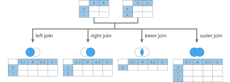

```python
# data reference - https://www.kaggle.com/vin1234/merge-join-and-concat-with-pandas
print('-- method 1 to create a dataframe : dictionary')
dummy_data1 = {
    'id': ['1', '2', '3', '4', '5'],
    'Feature1': ['A', 'C', 'E', 'G', 'I'],
    'Feature2': ['B', 'D', 'F', 'H', 'J']
}
df1 = pd.DataFrame(dummy_data1, columns = ['id', 'Feature1', 'Feature2'])
print('df1:\n', df1.to_markdown(tablefmt='grid'))
print('-- method 2 to create a dataframe : nd.array')
# dummy_data2 = {
#         'id': ['1', '2', '6', '7', '8'],
#         'Feature1': ['K', 'M', 'O', 'Q', 'S'],
#         'Feature2': ['L', 'N', 'P', 'R', 'T']}
dummy_data2 = [
    ['1', 'K', 'L'],
    ['2', 'M', 'N'],
    ['6', 'O', 'P'],
    ['7', 'Q', 'R'],
    ['8', 'S', 'T'],
]
df2 = pd.DataFrame(dummy_data2, columns = ['id', 'Feature1', 'Feature2'])
print('df2:\n', df2.to_markdown(tablefmt='grid'))
```

```
-- method 1 to create a dataframe : dictionary
df1:
 +----+------+------------+------------+
|    |   id | Feature1   | Feature2   |
+====+======+============+============+
|  0 |    1 | A          | B          |
+----+------+------------+------------+
|  1 |    2 | C          | D          |
+----+------+------------+------------+
|  2 |    3 | E          | F          |
+----+------+------------+------------+
|  3 |    4 | G          | H          |
+----+------+------------+------------+
|  4 |    5 | I          | J          |
+----+------+------------+------------+
-- method 2 to create a dataframe : nd.array
df2:
 +----+------+------------+------------+
|    |   id | Feature1   | Feature2   |
+====+======+============+============+
|  0 |    1 | K          | L          |
+----+------+------------+------------+
|  1 |    2 | M          | N          |
+----+------+------------+------------+
|  2 |    6 | O          | P          |
+----+------+------------+------------+
|  3 |    7 | Q          | R          |
+----+------+------------+------------+
|  4 |    8 | S          | T          |
+----+------+------------+------------+
```

### inner join

```python
df_inner = df1.merge(df2, on='id', how='inner')
df_inner
```

|  | id | Feature1_x | Feature2_x | Feature1_y | Feature2_y |
| --- | --- | --- | --- | --- | --- |
| 0 | 1 | A | B | K | L |
| 1 | 2 | C | D | M | N |

### left join

```python
df_left = df1.merge(df2, on='id', how='left', suffixes=('_left', '_right'))
df_left
```

|  | id | Feature1_left | Feature2_left | Feature1_right | Feature2_right |
| --- | --- | --- | --- | --- | --- |
| 0 | 1 | A | B | K | L |
| 1 | 2 | C | D | M | N |
| 2 | 3 | E | F | NaN | NaN |
| 3 | 4 | G | H | NaN | NaN |
| 4 | 5 | I | J | NaN | NaN |

```python
df_left = df1.merge(df2, left_on='id', right_on='id', how='left', suffixes=('_from_df1', '_from_df2'))
df_left
```

|  | id | Feature1_from_df1 | Feature2_from_df1 | Feature1_from_df2 | Feature2_from_df2 |
| --- | --- | --- | --- | --- | --- |
| 0 | 1 | A | B | K | L |
| 1 | 2 | C | D | M | N |
| 2 | 3 | E | F | NaN | NaN |
| 3 | 4 | G | H | NaN | NaN |
| 4 | 5 | I | J | NaN | NaN |

> - give it a try -
- how about merging multiple dataframes? e.g. inner join df1, df2, df3

```python
dummy_data3 = {
        'id': ['1', '2', '3', '4', '5', '7', '8', '9', '10', '11'],
        'Feature3': [12, 13, 14, 15, 16, 17, 15, 12, 13, 23]
}
df3 = pd.DataFrame(dummy_data3, columns = ['id', 'Feature3'])
df3
```

|  | id | Feature3 |
| --- | --- | --- |
| 0 | 1 | 12 |
| 1 | 2 | 13 |
| 2 | 3 | 14 |
| 3 | 4 | 15 |
| 4 | 5 | 16 |
| 5 | 7 | 17 |
| 6 | 8 | 15 |
| 7 | 9 | 12 |
| 8 | 10 | 13 |
| 9 | 11 | 23 |

```python
# your answer
```

### concat

[figure not shown]

```python
df_concat_horiz = pd.concat([df1, df2], axis=1)
print('df_concat_horiz:\n', df_concat_horiz.to_markdown(tablefmt='grid'))
print('--')
df_concat_vrt = pd.concat([df1, df2], axis=0)
print('df_concat_vrt:\n', df_concat_vrt.to_markdown(tablefmt='grid'))
```

```
df_concat_horiz:
 +----+------+------------+------------+------+------------+------------+
|    |   id | Feature1   | Feature2   |   id | Feature1   | Feature2   |
+====+======+============+============+======+============+============+
|  0 |    1 | A          | B          |    1 | K          | L          |
+----+------+------------+------------+------+------------+------------+
|  1 |    2 | C          | D          |    2 | M          | N          |
+----+------+------------+------------+------+------------+------------+
|  2 |    3 | E          | F          |    6 | O          | P          |
+----+------+------------+------------+------+------------+------------+
|  3 |    4 | G          | H          |    7 | Q          | R          |
+----+------+------------+------------+------+------------+------------+
|  4 |    5 | I          | J          |    8 | S          | T          |
+----+------+------------+------------+------+------------+------------+
--
df_concat_vrt:
 +----+------+------------+------------+
|    |   id | Feature1   | Feature2   |
+====+======+============+============+
|  0 |    1 | A          | B          |
+----+------+------------+------------+
|  1 |    2 | C          | D          |
+----+------+------------+------------+
|  2 |    3 | E          | F          |
+----+------+------------+------------+
|  3 |    4 | G          | H          |
+----+------+------------+------------+
|  4 |    5 | I          | J          |
+----+------+------------+------------+
|  0 |    1 | K          | L          |
+----+------+------------+------------+
|  1 |    2 | M          | N          |
+----+------+------------+------------+
|  2 |    6 | O          | P          |
+----+------+------------+------------+
|  3 |    7 | Q          | R          |
+----+------+------------+------------+
|  4 |    8 | S          | T          |
+----+------+------------+------------+
```

## to python basic data structures

```python
df1.head()
```

|  | id | Feature1 | Feature2 |
| --- | --- | --- | --- |
| 0 | 1 | A | B |
| 1 | 2 | C | D |
| 2 | 3 | E | F |
| 3 | 4 | G | H |
| 4 | 5 | I | J |

### to list

```python
df1['id'].tolist()
```

```
['1', '2', '3', '4', '5']
```

### to dict

```python
df_set_index = df1.set_index(['id'])['Feature1']
print('df_set_index:\n', df_set_index.to_markdown(tablefmt='grid'))
print(df_set_index.index)
```

```
df_set_index:
 +------+------------+
|   id | Feature1   |
+======+============+
|    1 | A          |
+------+------------+
|    2 | C          |
+------+------------+
|    3 | E          |
+------+------------+
|    4 | G          |
+------+------------+
|    5 | I          |
+------+------------+
Index(['1', '2', '3', '4', '5'], dtype='object', name='id')
```

```python
df1.set_index(['id'])['Feature1'].to_dict()
```

```
{'1': 'A', '2': 'C', '3': 'E', '4': 'G', '5': 'I'}
```

```python
df1.to_dict('records')
```

```
[{'id': '1', 'Feature1': 'A', 'Feature2': 'B'},
 {'id': '2', 'Feature1': 'C', 'Feature2': 'D'},
 {'id': '3', 'Feature1': 'E', 'Feature2': 'F'},
 {'id': '4', 'Feature1': 'G', 'Feature2': 'H'},
 {'id': '5', 'Feature1': 'I', 'Feature2': 'J'}]
```

### to set

```python
set(df1['id'])
```

```
{'1', '2', '3', '4', '5'}
```

```python
df1['id'].unique()
```

```
array(['1', '2', '3', '4', '5'], dtype=object)
```

```python
df1['id'].nunique()
```

```
5
```

```python
len(set(df1['id']))
```

```
5
```

# your turn

- use df_train to practice

### if you have trouble with the file path...

```python
import os
os.getcwd()
```

```
'/Users/johnson.huang/py_ds/tutor_python_project/notebooks'
```

```python
'Users' + os.sep + 'johnson.huang'
```

```
'Users/johnson.huang'
```

### read the data

```python
data_path_to_read_1 = '/Users/johnson.huang/py_ds/tutor_python_project/data/titanic/train.csv'  # absolute path
data_path_to_read_2 = '../data/titanic/train.csv'  # relative path
df_train = pd.read_csv(data_path_to_read_2)
df_train.head()
```

|  | PassengerId | Survived | Pclass | Name | Sex | Age | SibSp | Parch | Ticket | Fare | Cabin | Embarked |
| --- | --- | --- | --- | --- | --- | --- | --- | --- | --- | --- | --- | --- |
| 0 | 1 | 0 | 3 | Braund, Mr. Owen Harris | male | 22.0 | 1 | 0 | A/5 21171 | 7.2500 | NaN | S |
| 1 | 2 | 1 | 1 | Cumings, Mrs. John Bradley (Florence Briggs Th... | female | 38.0 | 1 | 0 | PC 17599 | 71.2833 | C85 | C |
| 2 | 3 | 1 | 3 | Heikkinen, Miss. Laina | female | 26.0 | 0 | 0 | STON/O2. 3101282 | 7.9250 | NaN | S |
| 3 | 4 | 1 | 1 | Futrelle, Mrs. Jacques Heath (Lily May Peel) | female | 35.0 | 1 | 0 | 113803 | 53.1000 | C123 | S |
| 4 | 5 | 0 | 3 | Allen, Mr. William Henry | male | 35.0 | 0 | 0 | 373450 | 8.0500 | NaN | S |

> - give it a try -
- select all rows (records) with 'Ticket' starts with A-Z alphabets, not integers